# Project machine learning

Valter Cruz Perez

Saturday, April 25, 2015

## Background

Using devices such as Jawbone Up, Nike FuelBand, and Fitbit it is now possible to collect a large amount of data about personal activity relatively inexpensively. These type of devices are part of the quantified self movement - a group of enthusiasts who take measurements about themselves regularly to improve their health, to find patterns in their behavior, or because they are tech geeks. One thing that people regularly do is quantify how much of a particular activity they do, but they rarely quantify how well they do it.

The aim of this report was to use data from accelerometers placed on the belt, forearm, arm, and dumbell of six participants to predict how well they were doing the exercise in terms of the classification in the data.

## Packagues and libraries

```r
library(caret)
```

```r
library(corrplot)
library(kernlab)
library(knitr)
library(randomForest)
library(lattice)
library(ggplot2)
library(rpart)
library(rpart.plot)
library(RColorBrewer)
library(rattle)
```

## Setup URL and download data

```r
f1 <- "http://d396qusza40orc.cloudfront.net/predmachlearn/pml-training.csv"
f2 <- "http://d396qusza40orc.cloudfront.net/predmachlearn/pml-testing.csv"
data.training <- read.csv(url(f1), na.strings=c("NA","#DIV/0!",""))
data.test <- read.csv(url(f2), na.strings=c("NA","#DIV/0!",""))
dateDownloaded <- date()
```

## clean data frame

```r
# clean the data by removing columns with NAs etc
f1 <- "http://d396qusza40orc.cloudfront.net/predmachlearn/pml-training.csv"
data.training <- read.csv(url(f1), na.strings=c("NA","#DIV/0!",""))
data.training.NA <- apply(data.training, 2, function(x) {sum(is.na(x))})
data.training.NONA <- data.training[,which(data.training.NA == 0)]

# remove identifier columns such as name, timestamps etc
data.training.NONA <- data.training.NONA[8:length(data.training.NONA)]
```

### Prepare data frame in to testing, training and test (cross validation)

```r
inTrain <- createDataPartition(y = data.training.NONA$classe, p = 0.7, list = FALSE)
training <- data.training.NONA[inTrain, ]
test <- data.training.NONA[-inTrain, ]
```

### Correlation test

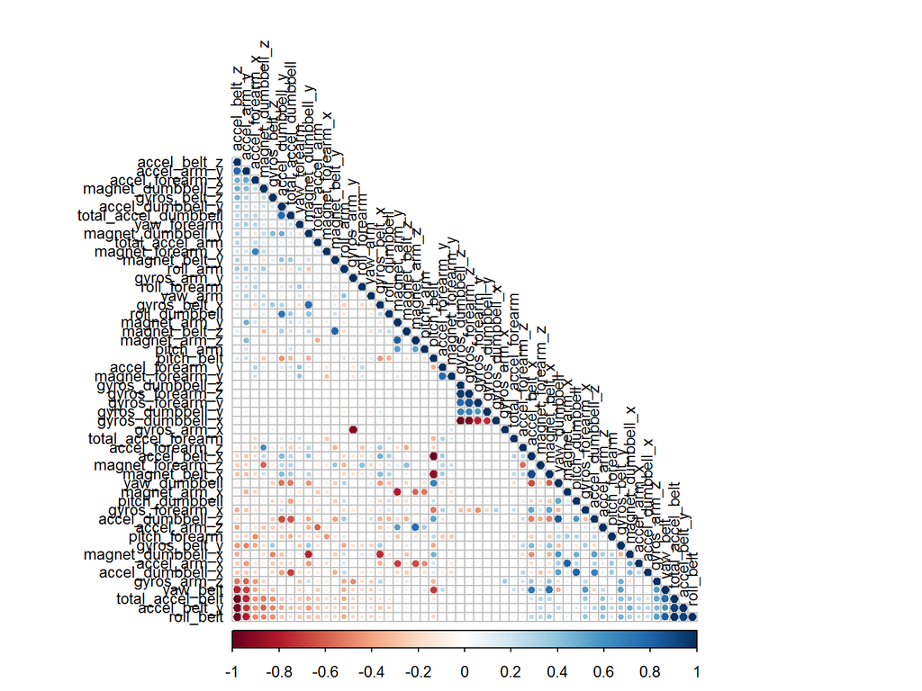

```r
# plot a correlation matrix
cor_matrix <- cor(training[, -length(training)])
corrplot(cor_matrix, order = "FPC", method = "circle", type = "lower", tl.cex = 0.8,  tl.col = rgb(0, 0, 0))
```

### Run fit model to predict the classe using the other variable

```r
# fit a model to predict the classe using everything else as a predictor
fit_model <- randomForest(classe ~ ., data = training)
```

### Create a crossvalidate with test data (test <- data.training.NONA[-inTrain, ]) this mean the 30% of ramaining data)

```r
# crossvalidate the model using the remaining 30% of data
prediction <- predict(fit_model, test)
confusionMatrix(test$classe, prediction)
```

```
## Confusion Matrix and Statistics
##
##           Reference
## Prediction    A    B    C    D    E
##          A 1674    0    0    0    0
##          B    5 1129    5    0    0
##          C    0   15 1009    2    0
##          D    0    0   18  946    0
##          E    0    0    1    4 1077
##
## Overall Statistics
##
##                Accuracy : 0.9915
##                  95% CI : (0.9888, 0.9937)
##     No Information Rate : 0.2853
##     P-Value [Acc > NIR] : < 2.2e-16
##
##                   Kappa : 0.9893
##  Mcnemar's Test P-Value : NA
##
## Statistics by Class:
##
##                      Class: A Class: B Class: C Class: D Class: E
## Sensitivity            0.9970   0.9869   0.9768   0.9937   1.0000
## Specificity            1.0000   0.9979   0.9965   0.9964   0.9990
## Pos Pred Value         1.0000   0.9912   0.9834   0.9813   0.9954
## Neg Pred Value         0.9988   0.9968   0.9951   0.9988   1.0000
## Prevalence             0.2853   0.1944   0.1755   0.1618   0.1830
## Detection Rate         0.2845   0.1918   0.1715   0.1607   0.1830
## Detection Prevalence   0.2845   0.1935   0.1743   0.1638   0.1839
## Balanced Accuracy      0.9985   0.9924   0.9866   0.9950   0.9995
```

# apply the same treatment to the final testing data

```r
f2 <- "http://d396qusza40orc.cloudfront.net/predmachlearn/pml-testing.csv"
data.test <- read.csv((f2), na.strings=c("NA","#DIV/0!",""))
data.test.NA <- apply(data.test, 2, function(x) {sum(is.na(x))})
data.test.NONA <- data.test[,which(data.test.NA == 0)]
data.test.NONA <- data.test.NONA[8:length(data.test.NONA)]
```

# predict the classes of the test set

```r
predictTest <- predict(fit_model, data.test.NONA)
predictTest
```

```
##  1  2  3  4  5  6  7  8  9 10 11 12 13 14 15 16 17 18 19 20
##  B  A  B  A  A  E  D  B  A  A  B  C  B  A  E  E  A  B  B  B
## Levels: A B C D E
```